# Homework 2 - Chapter 2

## Question 1 (ISLR Chapter 2 Exercise 2) [Continued]

[15 pt]

Explain whether each scenario is a classification or regression problem.

1. We collect a set of data on the top 500 firms in the US. For each firm we record profit, number of employees, industry and the CEO salary. We are interested in understanding which factors affect CEO salary.
2. We are considering launching a new product and wish to know whether it will be a success or a failure. We collect data on 20 similar products that were previously launched. For each product we have recorded whether it was a success or failure, price charged for the product, marketing budget, competition price, and ten other variables.
3. We are interested in predicting the % change in the USD/Euro exchange rate in relation to the weekly changes in the world stock markets. Hence we collect weekly data for all of 2012. For each week we record the % change in the USD/Euro, the % change in the US market, the % change in the British market, and the % change in the German market.

## Question 2

[85 pt]

Revisit the code for creating Figure 2.9. Your task is to add two more curves to the plot, representing the MSE for the Estimator for the training and test sets. In addition, please add points that indicate the values of the MSEE for the models with 2 degrees of freedom, 5 degrees of freedom, 23 degrees of freedom, and the model with the lowest MSEE for testing (on both curves).

One way to do so is suggested in the following code, which expands the code from class for the creation of Figure 2.9. You may complete the code (replace occurrences of `""` with actual code) to fulfill the task, or choose alternative ways to do so:

```r
f_2_9 <- function(x) {
  -4.5 * ((x - 10) / 50)^3 + 9 * ((x - 10) / 50)^2 + 4.2
}

x_range_tibble <- tibble(x = c(0, 100))

set.seed(1)
n_train <- 45
n_test <- 15
var_epsilon <- 2

test_data <-
  tibble(
    x = runif(n = n_test, min = 0, max = 100),
    true_f_x = f_2_9(x),
    y = true_f_x + rnorm(n_test, sd = sqrt(var_epsilon)),
    type = "te"
  )

train_data <-
  tibble(
    x = runif(n = n_train, min = 0, max = 100),
    true_f_x = f_2_9(x),
    y = true_f_x + rnorm(n_train, sd = sqrt(var_epsilon)),
    type = "tr"
  )

df_seq <- seq(2, 25, 0.1)
MSEP <- tibble(df = rep(NA, length(df_seq)), train = NA, test = NA)
MSEE <- ""

for(i in 1:length(df_seq)) {
  MSEP$df[i] <- df_seq[i]
  MSEE$df[i] <- ""

  smsp_2_9 <- smooth.spline(x = train_data$x, y = train_data$y, df = df_seq[i])

  pred_train <- predict(smsp_2_9, x = train_data$x)
  MSEP$train[i] <- mean( (train_data$y - pred_train$y) ^ 2 )
  MSEE$train[i] <- ""

  pred_test <- predict(smsp_2_9, x = test_data$x)
  MSEP$test[i] <- mean( (test_data$y - pred_test$y) ^ 2 )
  MSEE$test[i] <- ""
}

MSEP$type <- "MSEP"
MSEE$type <- "MSEE"

MSE <- bind_rows(MSEP, MSEE)

MSE_long <- pivot_longer(MSE, cols = c(train, test), names_to = "Subset", values_to = "MSE")

g_MSE <-
  ggplot(MSE_long) +
  geom_line(aes(x = df, y = MSE, color = "", linetype = "")) +
  theme_bw()

min_MSEP_test_df <-
  MSEP %>%
  filter(test == min(test)) %>%
  pull(df)

min_MSEE_test_df <- ""

g_MSE +
  xlab("Flexibility") +
  ylab("Mean Squared Error") +
  geom_point(
    data = MSE_long %>% filter(df %in% c(2, 5, 23)),
    color = rep(c("orange", "orange", "blue", "blue", "green", "green"), 2),
    shape = "square"
    ) +
  geom_point(
    data = MSE_long %>% filter(df == min_MSEP_test_df, type == "MSEP"),
    color = "black",
    shape = "X",
    size = 3
    ) +
  geom_point(
    data = MSE_long %>% filter(df == min_MSEE_test_df, type == "MSEE"),
    color = "black",
    shape = "X",
    size = 3
    )
```

Your final plot should look like this:

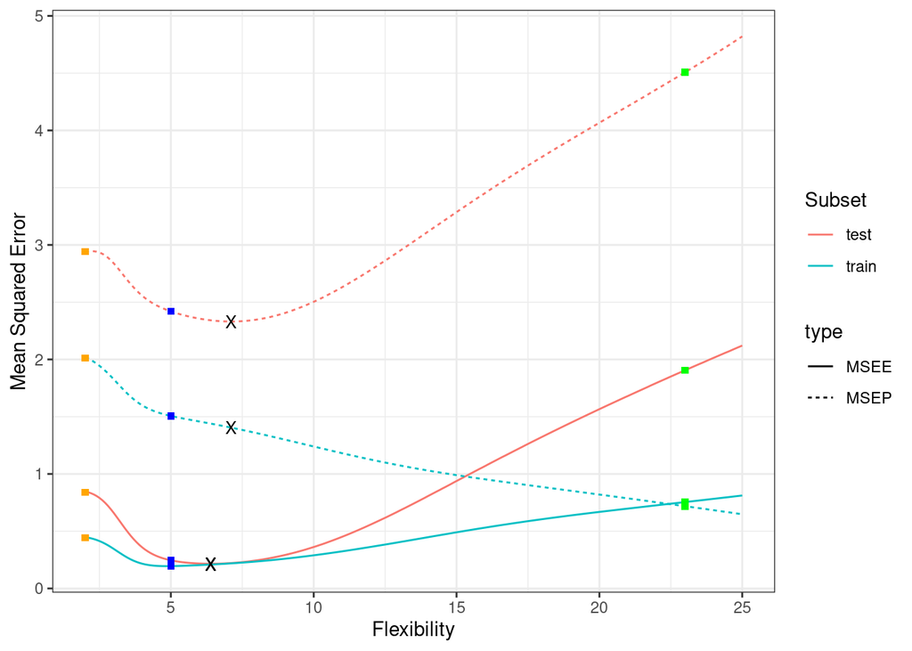

Answer the following questions:

1. What do you learn from this plot?
2. What is the distance between the curves for MSEP for the training and test set? How does this correspond to the theoretical results from slides 46-47 (in the annotated lecture notes from Feb 13)?
3. How is what we see in the plot you created reflected in the left-panel of Figure 2.9 (below)?

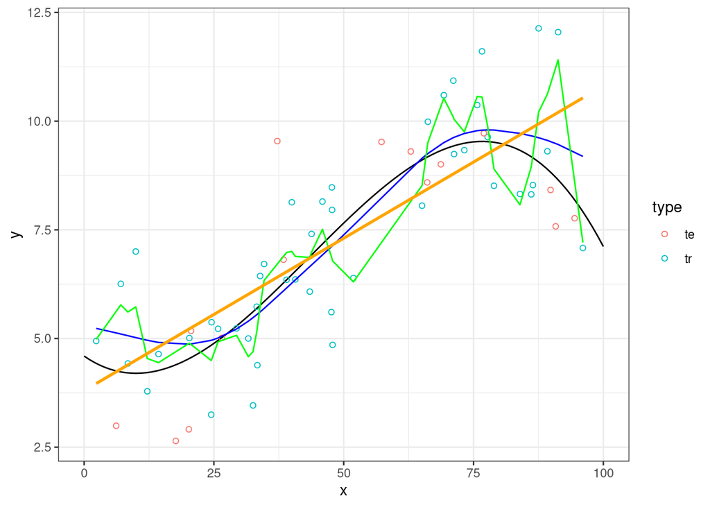